# SVM_Twitter

Uso del modelo SVM para analizar data en Twitter

## Support Vector Machine en R

EN este ejemplo se mostrará el uso del modelo SVM en R, el cuál se aplicará a una data obtenida de Twitter con el fin de hacer una clasificación. La misma snos indicará y nos ayudará a determinar si la opinión de un tweet en específico es positiva ó negativa.

```
#cargo librerias
#cargo librerias
library("devtools")
library("tm")


#paquetes de machine learning
library(caTools)
library(caret)



##

library(e1071)


#nube de palabras
library(wordcloud)
```

La base de datos a usar será “tweets.csv”, la cual se obtuvo luego de una consulta a través de Google Drive, la misma muestra la información obtenida al realizar una busqueda sobre “Apple”. Cabe destacar que esta consulta también se pudo haber hecho mediante la API de Twitter, en este caso el límite de los tweets a obtener ronda los 18.000 cada 15 minutos.

```
#leo base de datos de Tweets que baje usando google Drive
tweets <- read.csv(paste0(getwd(),"/Data/tweets.csv"))

#tomo 1era fila para colocar nombre a columnas
a <- tweets[1,]
for(i in 1:length(a)){
  a[[i]] <- as.character(a[[i]])
}

#pongo nombre a columnas
names(tweets) <- a
tweets <- tweets[-1,]

data <- data.frame(texto=as.character(tweets$`Tweet Text`))

head(data)

##                                                                                                                                                                                                                                  texto
## 1                                                                                                                                                                                          Die neuen Apple Zahlen sind da – alle Infos
## 2                                                                                                                                                                                      Top five MJ song \U0001f60c\U0001f60c\U0001f60c
## 3
## 4                                                                                                                                                                                             C’est le meilleur son de son album frère
## 5 ** THE #APPLE RULES ** $AAPL Q3 19 Earnings: - Revenue: $53.8B (exp $53.35B) - EPS: $2.18 (exp $2.10) - iPhone Revenue: $25.99B (exp $26.54B) - Services Revenue: $11.46B (exp $11.88B) - Sees Q4 Revenue $61B To $64B (exp $61.04B)
## 6
```

Una vez obtenida la data es necesario pre-procesarla con el fin de obtener una clasificación positiva (1) o negativa (-1) a cada Tweet, a modo de ejemplo y con el fin de mostrar como funciona el modelo se asignará al azar un valor a cada tweet obtenido.

```
#creo columna de 1 y -1
f <- rbinom(length(data$texto),1,0.7)
f[which(f==0)] <- -1

data$sent <- f

table(data$sent)

##
##   -1    1
##  981 2321
```

Para empezar se debe transformar el texto de cada tweet a un formato Corpus, y de la manera siguiente podemos acceder a su información,

```
#preprocesamiento
#convierto texo del tweet a objeto corpus
corpus <- Corpus(VectorSource(data$texto))
length(corpus)

## [1] 3302

#ingreso a la informacion en el objeto
content(corpus[[20]])

## [1] "Always enjoy #olderandwider but particularly enjoyed \u2066@jennyeclair\u2069 and \u2066@greyprideuk\u2069 chatting to \u2066@ArabellaWeir\u2069 tonight so sad so funny. Wonder if show will be in London after Edinburgh? If so I’m there."
```

El primer cambio a realizar, es cambiar todas la letras mayusculas a minusculas, esto se logra mediante los siguientes comandos,

```
#cambio letras mayusculas a minusculas
corpus1 <- tm_map(corpus,tolower)

## Warning in tm_map.SimpleCorpus(corpus, tolower): transformation drops
## documents

#realizo transformacion de data anterios
corpus1 <- tm_map(corpus1,PlainTextDocument)

## Warning in tm_map.SimpleCorpus(corpus1, PlainTextDocument): transformation
## drops documents

#accedo a informacion del nuevo objeto
content(corpus1[[1]])[20]

## [1] "always enjoy #olderandwider but particularly enjoyed \u2066@jennyeclair\u2069 and \u2066@greyprideuk\u2069 chatting to \u2066@arabellaweir\u2069 tonight so sad so funny. wonder if show will be in london after edinburgh? if so i’m there."
```

Luego de esto se procede a quitar signos de puntuación,

```
#quito puntuacion
corpus1 <- tm_map(corpus1,removePunctuation)

#accedo a informacion del nuevo objeto
content(corpus1[[1]])[20]

## [1] "always enjoy olderandwider but particularly enjoyed \u2066jennyeclair\u2069 and \u2066greyprideuk\u2069 chatting to \u2066arabellaweir\u2069 tonight so sad so funny wonder if show will be in london after edinburgh if so i’m there"
```

Otro aspecto importante a considerar son las “stop words”, las cuales son palabras que se usan como conectores y no representan o no nos dan información relevante, por tal motivo las mismas se eliminarán del texto de cada tweet. Existen “stop words” tanto en ingles como en español y las mismas ya se encuentran prefijadas en los paquetes instalados,

```
#quito stop words
#primeras palabras
stopwords("english")[1:10]

##  [1] "i"         "me"        "my"        "myself"    "we"
##  [6] "our"       "ours"      "ourselves" "you"       "your"

stopwords("spanish")[1:10]

##  [1] "de"  "la"  "que" "el"  "en"  "y"   "a"   "los" "del" "se"

#quito stopwords
#existen problemas con caracter "’", lo quite manualmente
corpus1 <- tm_map(corpus1,removeWords,c(stopwords("english"),"apple","’"))

#accedo a informacion del nuevo objeto
content(corpus1[[1]])[20]

## [1] "always enjoy olderandwider  particularly enjoyed \u2066jennyeclair\u2069  \u2066greyprideuk\u2069 chatting  \u2066arabellaweir\u2069 tonight  sad  funny wonder  show will   london  edinburgh   m "
```

Finalmente, se debe cambiar cada palabra a su forma base o raíz esto es cada palabra o verbo que esté conjugado se debe pasar a su forma base o verbo.

```
#modifico palabras a su raiz
corpus1 <- tm_map(corpus1,stemDocument)

#accedo a informacion del nuevo objeto
content(corpus1[[1]])[20]

## [1] "alway enjoy olderandwid particular enjoy \u2066jennyeclair\u2069 \u2066greyprideuk\u2069 chat \u2066arabellaweir\u2069 tonight sad funni wonder show will london edinburgh m"
```

Una vez realizado este proceso de limpieza se procede a crear una matriz de frecuencias, la cual nos va a proporcionar información sobre la frecuencia de uso de cada palabra,

```
#creo matriz de frecuencias
#creo nuevo corpus con data limpia
corpus2 <- Corpus(VectorSource(as.character(content(corpus1[[1]]))))

frecuencies <- DocumentTermMatrix(corpus2)

#veo matriz
inspect(frecuencies[800:805,505:515])

## <<DocumentTermMatrix (documents: 6, terms: 11)>>
## Non-/sparse entries: 0/66
## Sparsity           : 100%
## Maximal term length: 9
## Weighting          : term frequency (tf)
## Sample             :
##      Terms
## Docs  1240pm foxbusi get pacif readi tune despit thing actualiza algún amo
##   800      0       0   0     0     0    0      0     0         0     0   0
##   801      0       0   0     0     0    0      0     0         0     0   0
##   802      0       0   0     0     0    0      0     0         0     0   0
##   803      0       0   0     0     0    0      0     0         0     0   0
##   804      0       0   0     0     0    0      0     0         0     0   0
##   805      0       0   0     0     0    0      0     0         0     0   0
```

Debido a la forma de esta matriz la misma contará con una gran cantidad de ceros, por tal motivo usaremos el comando “removeSparseTerms” para remover y no considerar esta gran cantidad de datos, esto se logra mediante los siguientes comandos,

```
#encuento frecuencia
findFreqTerms(frecuencies,lowfreq = 50)

##  [1] "song"          "210"           "218"           "aapl"
##  [5] "earn"          "iphon"         "revenu"        "see"
##  [9] "servic"        "via"           "will"          "year"
## [13] "2019"          "like"          "third"         "work"
## [17] "digit"         "make"          "itun"          "love"
## [21] "podcast"       "want"          "news"          "ipad"
## [25] "per"           "one"           "watch"         "quarter"
## [29] "trade"         "billion"       "stock"         "now"
## [33] "can"           "spotifi"       "trump"         "report"
## [37] "result"        "sale"          "angel"         "california"
## [41] "elect"         "law"           "los"           "new"
## [45] "requir"        "return"        "tax"           "time"
## [49] "just"          "que"           "—"             "microsoft"
## [53] "app"           "appl"          "music"         "beat"
## [57] "expect"        "get"           "free"          "googl"
## [61] "est"           "share"         "today"         "listen"
## [65] "download"      "access"        "data"          "health"
## [69] "patient"       "standard"      "test"          "2019年7月31日"
## [73] "sleepmeist"    "時刻"          "play"          "store"
## [77] "android"

#reduzco matriz
sparse <- removeSparseTerms(frecuencies,0.995)
sparse

## <<DocumentTermMatrix (documents: 3302, terms: 246)>>
## Non-/sparse entries: 10577/801715
## Sparsity           : 99%
## Maximal term length: 10
## Weighting          : term frequency (tf)

#convierto matriz a dataframe
tweetsSparse <- as.data.frame(as.matrix(sparse))

colnames(tweetsSparse) <- make.names(colnames(tweetsSparse))
tweetsSparse$sentiment <- data$sent
```

Una vez eliminado esta data, se procederá a dividir la misma en dos, una data de entrenamiento y una data de prueba, esto se realiza mediante el comando “sample.split”, donde le decimos que queremos generar unos indices de manera tal que el 80% sea data de entrenamiento y el 20% restante sea data de prueba,

```
#maquina de soporte vectorial
#dividir data en un 80% entrenamiento y un 20% para evaluar

set.seed(12)

split <- sample.split(tweetsSparse$sentiment,SplitRatio = 0.8)

#creo data de entrenamiento y data de evaluacion
trainSparse <- subset(tweetsSparse,split==TRUE)
testSparse <- subset(tweetsSparse,split==FALSE)
testSparse$sentiment <- as.factor(testSparse$sentiment)

table(testSparse$sentiment)

##
##  -1   1
## 196 464
```

De esta manera uso la data de entrenamiento “trainSparse”, para correr y calibrar el modelo, esto usando la funcion “svm”, posteriormente se muestra un resumen del modelo,

```
#ejecuto modelo
SVM <- svm(as.factor(sentiment)~.,data = trainSparse)

summary(SVM)

##
## Call:
## svm(formula = as.factor(sentiment) ~ ., data = trainSparse)
##
##
## Parameters:
##    SVM-Type:  C-classification
##  SVM-Kernel:  radial
##        cost:  1
##       gamma:  0.004065041
##
## Number of Support Vectors:  2057
##
##  ( 1272 785 )
##
##
## Number of Classes:  2
##
## Levels:
##  -1 1
```

Luego de obtener el modelo, se pueden realizar predicciones usando la data de prueba “testSparse”, para luego evaluar los resultados y generar una matriz de confusión,

```
#realizo predicciones
predictSVM <- predict(SVM,newdata = testSparse)

#realizo prueba de la prediccion
confusionMatrix(predictSVM,testSparse$sentiment)

## Confusion Matrix and Statistics
##
##           Reference
## Prediction  -1   1
##         -1   4   6
##         1  192 458
##
##                Accuracy : 0.7
##                  95% CI : (0.6634, 0.7348)
##     No Information Rate : 0.703
##     P-Value [Acc > NIR] : 0.5865
##
##                   Kappa : 0.0103
##  Mcnemar's Test P-Value : <2e-16
##
##             Sensitivity : 0.020408
##             Specificity : 0.987069
##          Pos Pred Value : 0.400000
##          Neg Pred Value : 0.704615
##              Prevalence : 0.296970
##          Detection Rate : 0.006061
##    Detection Prevalence : 0.015152
##       Balanced Accuracy : 0.503739
##
##        'Positive' Class : -1
##
```

## Nube de palabras

Con el fin de gráficar la información obtenida, la nube de palabras es una buena opción en este caso, sólo se considerarán las palabras positivas, en esta nube mientras más grande sea la palabra mayor fué su uso.

[output not shown]

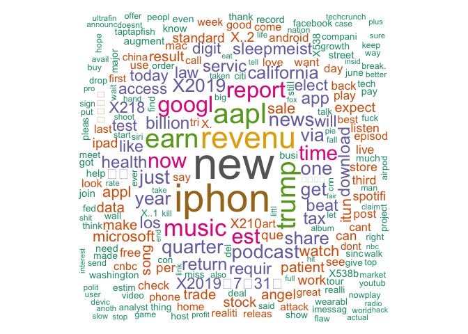